# A hypothesis test of feasibility for external pilot trials assessing recruitment, follow-up and adherence rates

Leeds Institute of Clinical Trials Research

## Motivation

- The success of a large, definitve Complex intervention RCT can depend on things like **recruitment**, **follow-up** and **adherence** rates.
- When these are unknown, we risk running the trial only to find out it’s **infeasible** - a waste of time and money.
- To avoid this, we often run a small pilot trial to estimate these rates and guide the **stop/go decision**.

For example, proceed only if:

- Recruitment rate > 0.4;
- Follow-up rate > 0.6;
- Adherence rate > 0.8.

## Motivation

- …*but*, setting these decision rules is challenging:
  - If they are **too lax**, we will often proceed to infeasible trials;
  - If they are **too strict**, we will often discard promising interventions;
  - If the pilot estimates are **too variable**, we will make mistakes.

**How can we determine optimial decision rules and pilot sample sizes?**

## Content

We will:

- Use a **hypothesis testing framework**;
- Define a test **statistic**;
- Show how **type I and II error rates** can be determined;
- Use these operating characteristics to **optimise** the decision rule and pilot sample size;
- Apply the method to an example, and **compare** it with a more typical approach.

## Set-up

Definitive trial: two-arm parallel group, with a normally distributed primary outcome with known variance.

We are interested in:

- Recruitment rate, \(\phi_r\);
- Follow-up rate, \(\phi_f\);
- Adherence rate, \(\phi_a\).

We denote the parameter vector by \(\phi = (\phi_r, \phi_f, \phi_a)\), and the pilot estimate by \(\hat{\phi} = (\hat{\phi}_r, \hat{\phi}_f, \hat{\phi}_a)\).

Our problem is to choose an appropriate decision rule, \[ d(\hat{\phi}): [0,1]^3 \rightarrow \{stop, go\} \] together with a pilot sample size, \(n_p\).

## Test

Quantify feasibility as the power we will have in the definitive trial, denoted \(f(\phi)\).

A test statistic: \(f(\hat{\phi})\) - the estimated power, given the pilot estimates \(\hat{\phi}\).

Our decision rule requires a cut-off value \(c\): \[ d[f(\hat{\phi})] = \begin{cases} stop ~\text{ if } f(\hat{\phi}) \leq c, \\ go ~~~~\text{ if } f(\hat{\phi}) > c. \end{cases} \]

## Operating characteristics

Due to the sampling variation in \(\hat{\phi}\) we might make mistakes. For example, \[ f(\phi) = 0.9 - \text{ feasible, want to proceed; } \\ f(\hat{\phi}) = 0.6 < c \Rightarrow stop, ~ \text{ a type II error.} \] Similarly, \[ f(\phi) = 0.5 - \text{ infeasible, want to stop; } \\ f(\hat{\phi}) = 0.75 > c \Rightarrow go, ~ \text{ a type I error.} \]

## Hypotheses

Suppose \(p_0 = 0.6\) and \(p_1 = 0.8\).

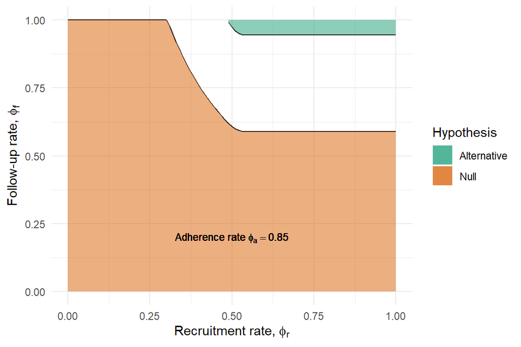

## Hypotheses

Suppose \(p_0 = 0.6\) and \(p_1 = 0.8\).

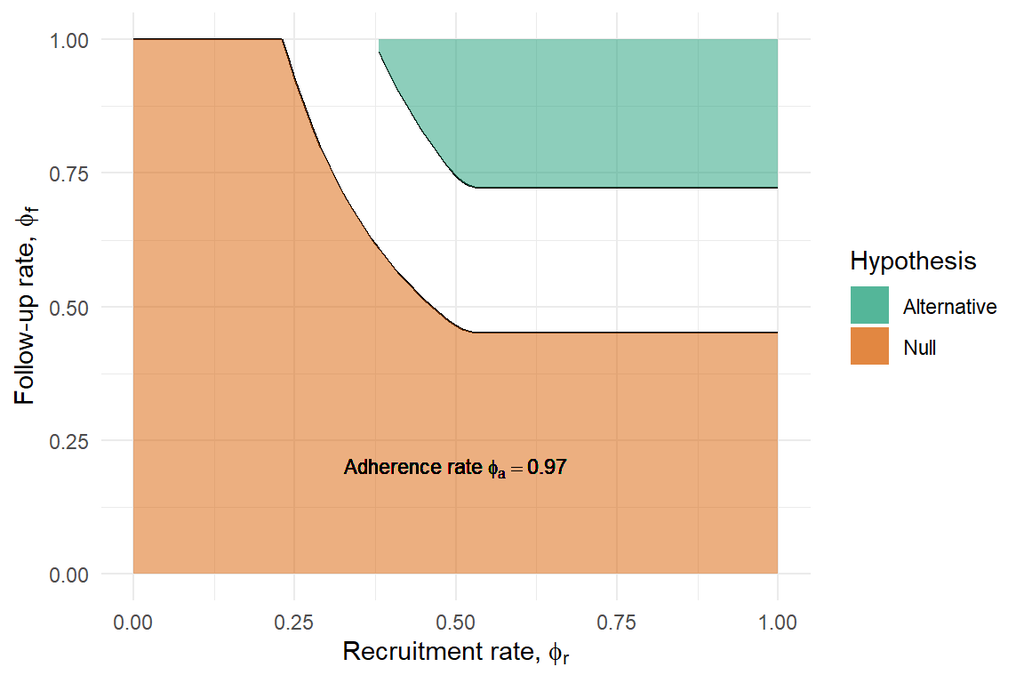

## Progression criteria

Having defined hypotheses, we can calculate error rates for any kind of decision rule.

For example, **proceed** to the definitive trial **only if**:

- Recruitment rate \(\hat{\phi}_r > c_r = 0.4\), and
- follow-up rate \(\hat{\phi}_f > c_f = 0.6\), and
- adherence rate \(\hat{\phi}_a > c_a = 0.8\).

In this case, we now want to choose \(n_p\) and the three progression criteria thresholds, \(c_r, c_f\) and \(c_a\), based on the error rates they lead to.

## Application

Planned definitive trial:

Our pilot trial hypotheses:

- a true power of more than \(80\% \Rightarrow\) feasible, and we don’t want to miss this - so, \(p_1 = 0.8\);
- a true power of less than \(60\% \Rightarrow\) infeasible, and should be avoided - so, \(p_0 = 0.6\).

## Results

[figure not shown]

## Results

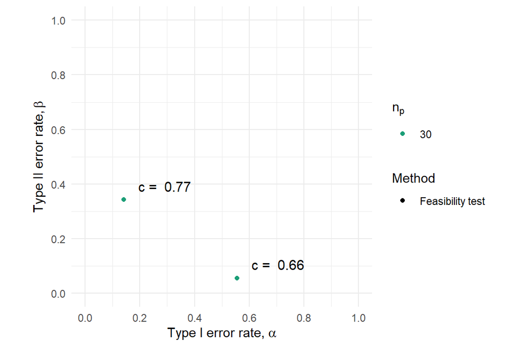

## Results

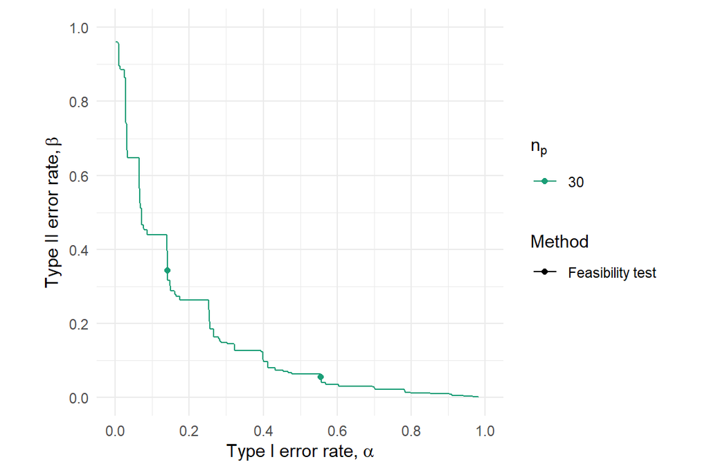

## Results

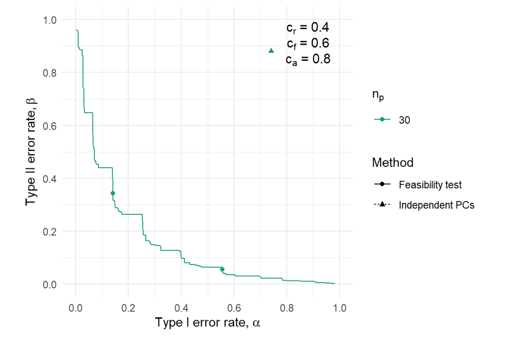

## Results

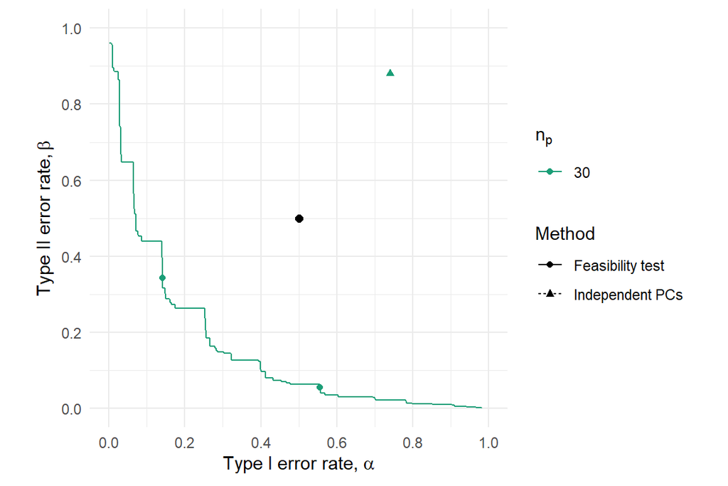

## Results

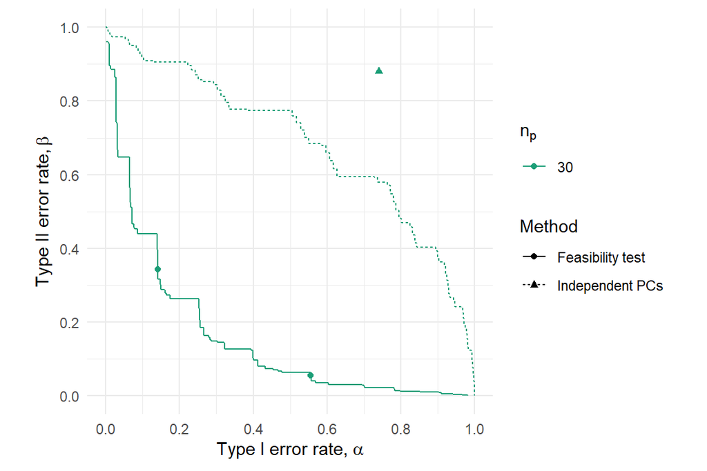

## Results

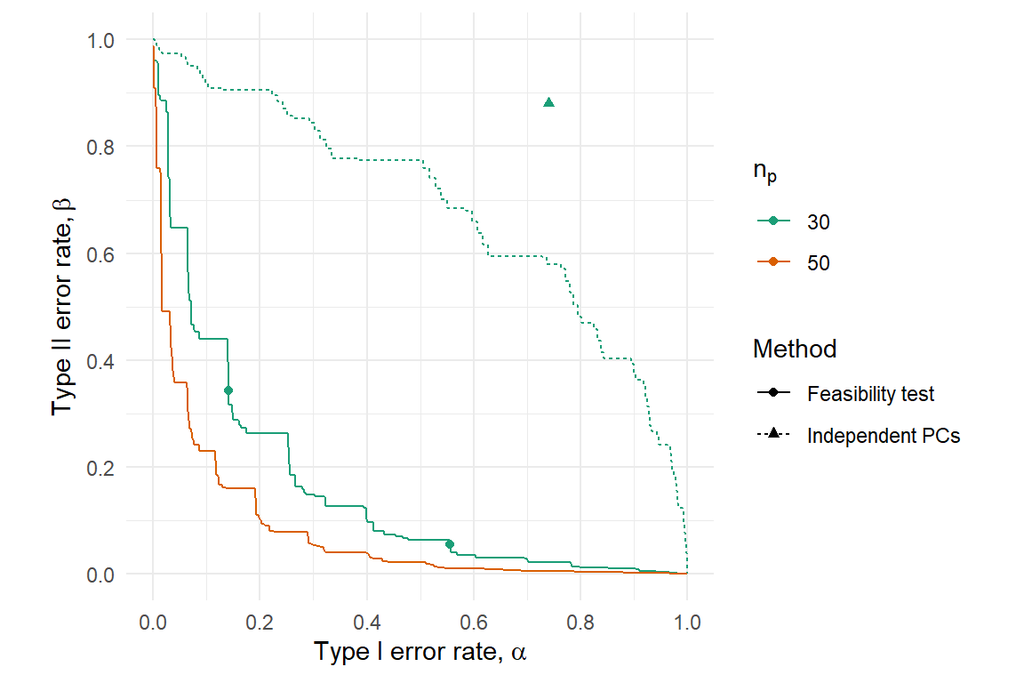

## Conclusions

Key points:

- The proposed test can provide conventional error rates with a pilot sample size of between 30 and 50 participants per arm;
- More conventional progression criteria, based on several independent thresholds, can have very poor error rates.

Extensions:

- We have assumed known variance, but this can be relaxed (see pre-print);
- If only a subset of the parameters considered here are of interest, the method reduces down easily.

Thank you

- Pre-print on arXiv
- Paper, slides and all code are at https://github.com/DTWilson/Feasibility_test
- Contact: @DTWilson, d.t.wilson@leeds.ac.uk
- Plug - poster P5

[figure not shown]